[figure not shown]

# Cardio Good Fitness Project

[figure not shown]

### **Objective**

The Cardio Good Fitness is a retail store which sells various products of treadmills to customers. The store caters to the needs of different categories of customers. The dataset derived has different attributes which provides an insight on the buying patterns of customer. The store would like to understand the pattern of the purchaase of treadmills across different age groups, Gender specific, Marital status , Fitness quotient and many more. The data will provide an insight to the store in customizing their offerings to the end customers

Let us first import the necessary libraries before starting our analysis.

### **Importing the libraries**

```python
# Libraries to help with reading and manipulating data
import numpy as np
import pandas as pd

# Libraries to help with data visualization
import matplotlib.pyplot as plt
import seaborn as sns

# Command to tell Python to actually display the graphs
%matplotlib inline
```

Let us now load the dataset.

### **Loading the dataset**

```python
# read the dataset
url = 'https://raw.githubusercontent.com/Seprishi/CardioGoodFitnessProject/main/CardioGoodFitness.csv'
data = pd.read_csv(url, index_col=0)
```

### **Overview of the dataset**

### **DataSet Details**

The dataset consists of the following features:

1. **Product** - The model no. of the treadmill
2. **Age** - Age of the customer in no of years
3. **Gender** - Gender of the customer
4. **Education** - Education of the customer in no. of years
5. **Marital Status** - Marital status of the customer
6. **Usage** - Avg. # times the customer wants to use the treadmill every week
7. **Fitness** - Self rated fitness score of the customer (5 - very fit, 1 - very unfit)
8. **Income** - Income of the customer
9. **Miles**- Miles that a customer expects to run

#### **Verifying the dataset loaded properly by displaying the first 5 rows of the dataset**

```python
data.head()
```

| Product | Age | Gender | Education | MaritalStatus | Usage | Fitness | Income | Miles |
| --- | --- | --- | --- | --- | --- | --- | --- | --- |
| TM195 | 18 | Male | 14 | Single | 3 | 4 | 29562 | 112 |
| TM195 | 19 | Male | 15 | Single | 2 | 3 | 31836 | 75 |
| TM195 | 19 | Female | 14 | Partnered | 4 | 3 | 30699 | 66 |
| TM195 | 19 | Male | 12 | Single | 3 | 3 | 32973 | 85 |
| TM195 | 20 | Male | 13 | Partnered | 4 | 2 | 35247 | 47 |

```python
data.tail()
```

|  | Product | Age | Gender | Education | MaritalStatus | Usage | Fitness | Income | Miles |
| --- | --- | --- | --- | --- | --- | --- | --- | --- | --- |
| 175 | TM798 | 40 | Male | 21 | Single | 6 | 5 | 83416 | 200 |
| 176 | TM798 | 42 | Male | 18 | Single | 5 | 4 | 89641 | 200 |
| 177 | TM798 | 45 | Male | 16 | Single | 5 | 5 | 90886 | 160 |
| 178 | TM798 | 47 | Male | 18 | Partnered | 4 | 5 | 104581 | 120 |
| 179 | TM798 | 48 | Male | 18 | Partnered | 4 | 5 | 95508 | 180 |

- *The dataset contains information about the customers who are visiting the store to buy the treadmill products.*
- *It contains details about the customers age,Gender, Education, Marital status, usage type (frequency of the usage), Fitness score , Income and the miles.*

#### **Information about Data**

```python
data.info()
```

```
<class 'pandas.core.frame.DataFrame'>
RangeIndex: 180 entries, 0 to 179
Data columns (total 9 columns):
 #   Column         Non-Null Count  Dtype
---  ------         --------------  -----
 0   Product        180 non-null    object
 1   Age            180 non-null    int64
 2   Gender         180 non-null    object
 3   Education      180 non-null    int64
 4   MaritalStatus  180 non-null    object
 5   Usage          180 non-null    int64
 6   Fitness        180 non-null    int64
 7   Income         180 non-null    int64
 8   Miles          180 non-null    int64
dtypes: int64(6), object(3)
memory usage: 12.8+ KB
```

#### **Understanding the shape of the dataset**

```python
data.shape
```

```
(180, 9)
```

- *There are 180 rows and 9 columns in the dataset.*

#### **Checking the data types of the columns for the dataset**

```python
data.info()
```

```
<class 'pandas.core.frame.DataFrame'>
RangeIndex: 180 entries, 0 to 179
Data columns (total 9 columns):
 #   Column         Non-Null Count  Dtype
---  ------         --------------  -----
 0   Product        180 non-null    object
 1   Age            180 non-null    int64
 2   Gender         180 non-null    object
 3   Education      180 non-null    int64
 4   MaritalStatus  180 non-null    object
 5   Usage          180 non-null    int64
 6   Fitness        180 non-null    int64
 7   Income         180 non-null    int64
 8   Miles          180 non-null    int64
dtypes: int64(6), object(3)
memory usage: 12.8+ KB
```

- *The `Age`, `Education`, `Usage`, `Fitness`, `Income` and `Miles` columns are numerical columns and `Product`, `Gender`, `Marital Status`columns are categorical in nature.*

#### **Statistical Summary Of the Data**

```python
data.describe().T
```

|  | count | mean | std | min | 25% | 50% | 75% | max |
| --- | --- | --- | --- | --- | --- | --- | --- | --- |
| Age | 180.0 | 28.788889 | 6.943498 | 18.0 | 24.00 | 26.0 | 33.00 | 50.0 |
| Education | 180.0 | 15.572222 | 1.617055 | 12.0 | 14.00 | 16.0 | 16.00 | 21.0 |
| Usage | 180.0 | 3.455556 | 1.084797 | 2.0 | 3.00 | 3.0 | 4.00 | 7.0 |
| Fitness | 180.0 | 3.311111 | 0.958869 | 1.0 | 3.00 | 3.0 | 4.00 | 5.0 |
| Income | 180.0 | 53719.577778 | 16506.684226 | 29562.0 | 44058.75 | 50596.5 | 58668.00 | 104581.0 |
| Miles | 180.0 | 103.194444 | 51.863605 | 21.0 | 66.00 | 94.0 | 114.75 | 360.0 |

#### **Checking for null values in the Data**

```python
data.isna().any()
```

```
Product          False
Age              False
Gender           False
Education        False
MaritalStatus    False
Usage            False
Fitness          False
Income           False
Miles            False
dtype: bool
```

```python
data.isnull().sum()
```

```
Product          0
Age              0
Gender           0
Education        0
MaritalStatus    0
Usage            0
Fitness          0
Income           0
Miles            0
dtype: int64
```

*Observation* : No null values present in the data on the 9 columns

**Unique Values in columns**

```python
ColumnNames = ["Product", "Age", "Gender", "Education", "MaritalStatus", "Usage", "Fitness","Income","Miles"]
for temp in ColumnNames:
      print("----",temp,"--------")
      print(data[temp].unique())
```

```
---- Product --------
['TM195' 'TM498' 'TM798']
---- Age --------
[18 19 20 21 22 23 24 25 26 27 28 29 30 31 32 33 34 35 36 37 38 39 40 41
 43 44 46 47 50 45 48 42]
---- Gender --------
['Male' 'Female']
---- Education --------
[14 15 12 13 16 18 20 21]
---- MaritalStatus --------
['Single' 'Partnered']
---- Usage --------
[3 2 4 5 6 7]
---- Fitness --------
[4 3 2 1 5]
---- Income --------
[ 29562  31836  30699  32973  35247  37521  36384  38658  40932  34110
  39795  42069  44343  45480  46617  48891  53439  43206  52302  51165
  50028  54576  68220  55713  60261  67083  56850  59124  61398  57987
  64809  47754  65220  62535  48658  54781  48556  58516  53536  61006
  57271  52291  49801  62251  64741  70966  75946  74701  69721  83416
  88396  90886  92131  77191  52290  85906 103336  99601  89641  95866
 104581  95508]
---- Miles --------
[112  75  66  85  47 141 103  94 113  38 188  56 132 169  64  53 106  95
 212  42 127  74 170  21 120 200 140 100  80 160 180 240 150 300 280 260
 360]
```

*Observation*

1. There are 3 unique Products sold by the Cardio Good Fitness store
2. Both Partnered and Single customers are there
3. The usage of treadmill ranges from 2 times to 7 times per week
4. The Education levels of the users are between 12-21
5. The income range of customers buying treadmill starts at 29K and Maximum income of 104K.

#### **More Analysis**

```python
data.Product.value_counts()
```

```
TM195    80
TM498    60
TM798    40
Name: Product, dtype: int64
```

*TM195 model is bought by more number of customers*

```python
data.MaritalStatus.value_counts()
```

```
Partnered    107
Single        73
Name: MaritalStatus, dtype: int64
```

*Partnered Customers are more than the Single customers*

```python
data.Gender.value_counts()
```

```
Male      104
Female     76
Name: Gender, dtype: int64
```

*More Male customers are buying treadmills compared to the female customers*

```python
data.groupby(by = ['Fitness','Gender'])['Age'].mean()
```

```
Fitness  Gender
1        Female    31.000000
         Male      23.000000
2        Female    28.750000
         Male      27.500000
3        Female    28.577778
         Male      28.903846
4        Female    28.750000
         Male      28.125000
5        Female    27.333333
         Male      30.400000
Name: Age, dtype: float64
```

- *Fitness level of 2,3 and 4 are seen in 28 year old females on average*
- *For men the avg. age varies on each fitness level*

```python
data.groupby(by = ['Product','Gender'])['Age'].mean()
```

```
Product  Gender
TM195    Female    28.450000
         Male      28.650000
TM498    Female    29.103448
         Male      28.709677
TM798    Female    27.000000
         Male      29.545455
Name: Age, dtype: float64
```

*The Most Sold product TM195 is bought by both Male and Female customers of average Age 28*

```python
data.groupby(by = ['Product', 'Gender'])['Fitness'].mean()
```

```
Product  Gender
TM195    Female    2.875000
         Male      3.050000
TM498    Female    2.862069
         Male      2.935484
TM798    Female    4.571429
         Male      4.636364
Name: Fitness, dtype: float64
```

*TM798 model is bought by both male and female customers who are very fit*

```python
data.groupby(by = ['Fitness', 'Gender'])['Age'].mean()
```

```
Fitness  Gender
1        Female    31.000000
         Male      23.000000
2        Female    28.750000
         Male      27.500000
3        Female    28.577778
         Male      28.903846
4        Female    28.750000
         Male      28.125000
5        Female    27.333333
         Male      30.400000
Name: Age, dtype: float64
```

- *The Age group of customers with a Fitness score of 3 & 4 is 28-29 (Both Male and female)*
- *Very Fit customers are having average age of 27 in Females and 30 in case of Males*

```python
data.mode()
```

|  | Product | Age | Gender | Education | MaritalStatus | Usage | Fitness | Income | Miles |
| --- | --- | --- | --- | --- | --- | --- | --- | --- | --- |
| 0 | TM195 | 25 | Male | 16 | Partnered | 3 | 3 | 45480 | 85 |

- *Most Sold model is TM195 and used by Males with eduation level of 16*
- *These users are partnered with an income of 45K and their usage is 3 days per week and futness score is average score (3)*

```python
data.skew()
```

```
Age          0.982161
Education    0.622294
Usage        0.739494
Fitness      0.454800
Income       1.291785
Miles        1.724497
dtype: float64
```

- *The skewness of the dataset is positive in all features*

## **Univariate Analysis**

### **Understanding the distribution of Age, Income, Miles, Fitness, Usage(Numerical Variables)**

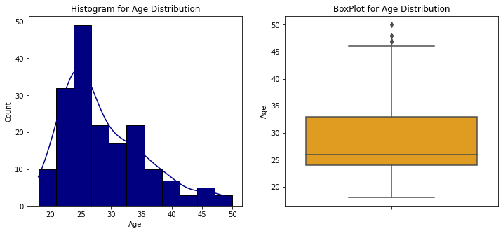

```python
plt.figure(figsize = (12,5))
plt.subplot(1,2,1)
sns.histplot(data=data, x='Age', kde = True, alpha =1,color = 'Navy', edgecolor = 'black'). set(title='Histogram for Age Distribution')       # creating a histogram for the Age
plt.subplot(1,2,2)
sns.boxplot(data = data, y='Age',color = 'Orange').set(title='BoxPlot for Age Distribution')      # creating a boxplot for the Age
```

- *The distribution of Age is right-skewed*
- *Age group of 20-30 are very active which implies youngsters are very fit*
- *Not many outliers are there for AGE in the dataset*

```
[Text(0.5, 1.0, 'BoxPlot for Income Distribution')]
```

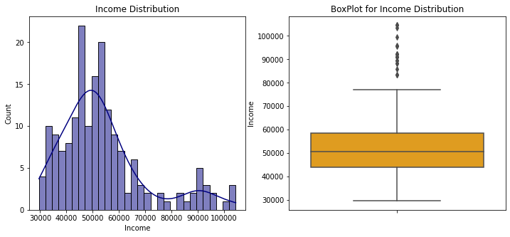

```python
plt.figure(figsize = (12,5))
plt.subplot(1,2,1)
sns.histplot(data=data, x='Income', kde = True, bins=30,color = 'NAVY', edgecolor = 'black'). set(title='Income Distribution')       # creating a histogram for the Income
plt.subplot(1,2,2)
sns.boxplot(data = data, y='Income',color = 'Orange').set(title='BoxPlot for Income Distribution')      # creating a boxplot for the Income
```

- *The distribution of Income is Right Skewed*
- *Many outliers are seen in the box plot*

```
[Text(0.5, 1.0, 'BoxPlot for Education Distribution')]
```

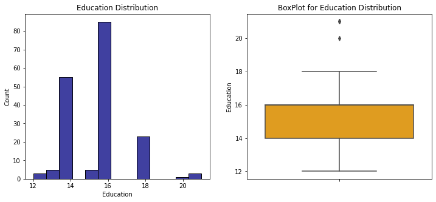

```python
plt.figure(figsize = (12,5))
plt.subplot(1,2,1)
sns.histplot(data=data, x='Education', color = 'Navy', edgecolor = 'black'). set(title='Education Distribution')       # creating a histogram for the Education
plt.subplot(1,2,2)
sns.boxplot(data = data, y='Education',color = 'Orange').set(title='BoxPlot for Education Distribution')      # creating a boxplot for the Education
```

- *25% has 12-14 years of education*
- *25% - 75% upto 16 years*

```
[Text(0.5, 1.0, 'BoxPlot for Fitness Distribution')]
```

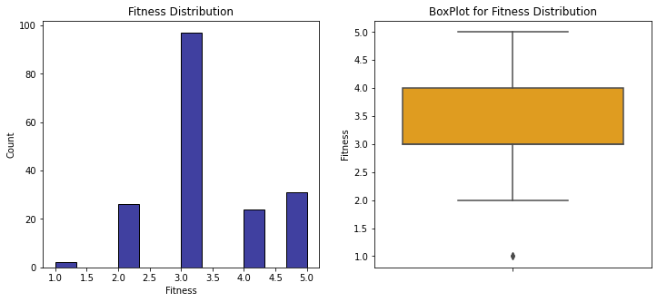

```python
plt.figure(figsize = (12,5))
plt.subplot(1,2,1)
sns.histplot(data=data, x='Fitness', color = 'Navy', edgecolor = 'black'). set(title='Fitness Distribution')       # creating a histogram for the Fitness
plt.subplot(1,2,2)
sns.boxplot(data = data, y='Fitness',color = 'Orange').set(title='BoxPlot for Fitness Distribution')      # creating a boxplot for the Fitness
```

- *Average Fitness score is 3.3 and most of the customers falls in the fitness score range between 3 & 4*

```
[Text(0.5, 1.0, 'BoxPlot for Miles Distribution')]
```

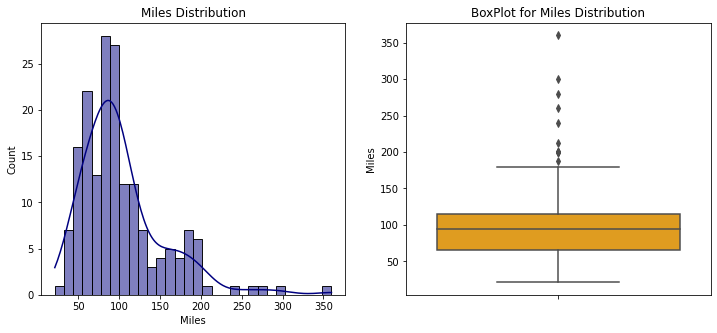

```python
plt.figure(figsize = (12,5))
plt.subplot(1,2,1)
sns.histplot(data=data, x='Miles', kde = True, bins =30, color = 'Navy', edgecolor = 'black'). set(title='Miles Distribution')       # creating a histogram for the Miles
plt.subplot(1,2,2)
sns.boxplot(data = data, y='Miles',color = 'Orange').set(title='BoxPlot for Miles Distribution')      # creating a boxplot for the Miles
```

- *The distribution of the miles data is Right Skewed*
- *Difference between Min and Max values are huge*
- *Many outliers are there in the data*

```
[Text(0.5, 1.0, 'BoxPlot for Usage Distribution')]
```

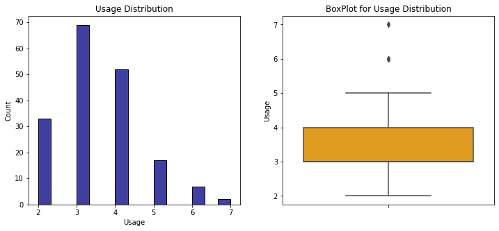

```python
plt.figure(figsize = (12,5))
plt.subplot(1,2,1)
sns.histplot(data=data, x='Usage', color = 'Navy', edgecolor = 'black'). set(title='Usage Distribution')       # creating a histogram for the Usage
plt.subplot(1,2,2)
sns.boxplot(data = data, y='Usage',color = 'Orange').set(title='BoxPlot for Usage Distribution')      # creating a boxplot for the Usage
```

- *The distribution is right skewed. This clearly implies the mean is greater than median*
- *Average use of Treadmill/product is 3 times a week*

## *Outlier Treatment*

From the plots, we can infer that there are many outliers for the Income and Miles columns and hence, this needs treatment

```python
Outliertreateddata = data.copy()
```

```python
#Outlier Treatment: Remove top 5% & bottom 1% of the Column Outlier values
Q3 = Outliertreateddata['Income'].quantile(0.75)
Q1 = Outliertreateddata['Income'].quantile(0.25)
IQR = Q3-Q1
Outliertreateddata = Outliertreateddata[(Outliertreateddata['Income'] > Q1 - 1.5*IQR) & (Outliertreateddata['Income'] < Q3 + 1.6*IQR)]

Q3 = Outliertreateddata['Miles'].quantile(0.75)
Q1 = Outliertreateddata['Miles'].quantile(0.25)
IQR = Q3-Q1
Outliertreateddata = Outliertreateddata[(Outliertreateddata['Miles'] > Q1 - 1.5*IQR) & (Outliertreateddata['Miles'] < Q3 + 1.5*IQR)]
```

```
[Text(0.5, 1.0, 'BoxPlot for Income Distribution')]
```

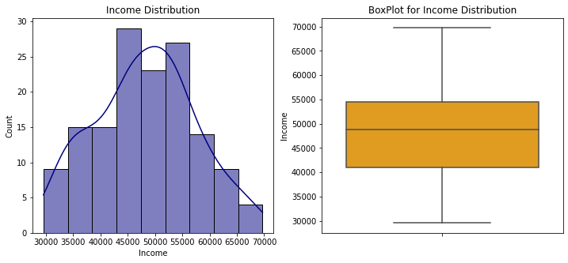

```python
plt.figure(figsize = (12,5))
plt.subplot(1,2,1)
sns.histplot(data=Outliertreateddata, x='Income', kde = True, color = 'NAVY', edgecolor = 'black'). set(title='Income Distribution')       # creating a histogram for the Income
plt.subplot(1,2,2)
sns.boxplot(data = Outliertreateddata, y='Income',color = 'Orange').set(title='BoxPlot for Income Distribution')      # creating a boxplot for the Income
```

```
[Text(0.5, 1.0, 'BoxPlot for Miles Distribution')]
```

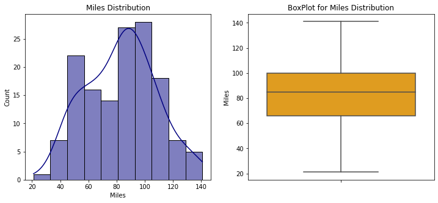

```python
plt.figure(figsize = (12,5))
plt.subplot(1,2,1)
sns.histplot(data=Outliertreateddata, x='Miles', kde = True, color = 'Navy', edgecolor = 'black'). set(title='Miles Distribution')       # creating a histogram for the Miles
plt.subplot(1,2,2)
sns.boxplot(data = Outliertreateddata, y='Miles',color = 'Orange').set(title='BoxPlot for Miles Distribution')      # creating a boxplot for the Miles
```

- *The Outliers are removed from the data and the plots showing the details of both income and Miles. However, for the integrity of data to keep the Max values for better modeling, we are continuing with the original dataset further*

### **Understanding the distribution of Product, Gender and Marital Status(Categorical Variables)**

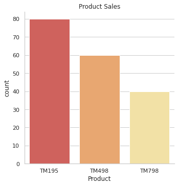

```python
plt.figure(figsize=(14,7))
sns.catplot(x = 'Product', data = data, kind = 'count');
plt.title("Product Sales")
plt.show()
```

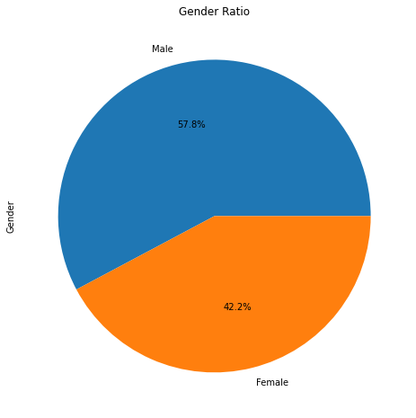

```python
plt.figure(figsize=(14,7))
data['Gender'].value_counts().plot.pie(autopct='%1.1f%%',figsize=(8,8))
plt.title("Gender Ratio")
plt.show()
```

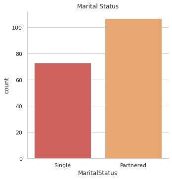

```python
plt.figure(figsize=(14,7))
sns.catplot(x = 'MaritalStatus', data = data, kind = 'count');
plt.title("Marital Status")
plt.show()
```

### *Observations*

- *TM195 is the most sold product*
- *57.8% of Males and 42.2% of Females are using the Treadmills*
- *Approx 100 of the customers are married and the remaining customers are single*

#### **Bi-Variate Analysis (Numeric Variables) to understand Customer characteristics**

*Relationship between Age and Miles*

```
[Text(0.5, 1.0, 'Lineplot for Age and Miles')]
```

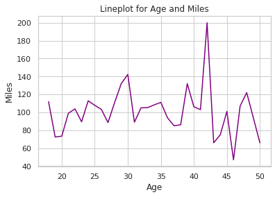

```python
sns.lineplot(x = 'Age', y = 'Miles', data = data, color = 'purple',ci = None).set(title='Lineplot for Age and Miles')
```

- From the graph, it is inferred that Customers of age 40 to 42 years run the maximum number of miles
- Miles run/week shows a steep drop in customers of age 42-43 and 45-47

*Relationship between Age and Fitness*

```
[Text(0.5, 1.0, 'Lineplot for Age and Fitness')]
```

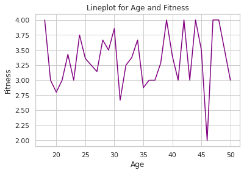

```python
sns.lineplot(x = 'Age', y = 'Fitness', data = data, color = 'purple',ci = None).set(title='Lineplot for Age and Fitness')
```

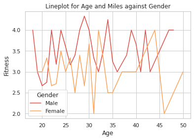

```python
sns.lineplot(data=data, x='Age', y='Fitness', ci=False, hue='Gender').set(title='Lineplot for Age and Miles against Gender');
```

*Relationship between Age and Income*

```
[Text(0.5, 1.0, 'Lineplot for Age and Income')]
```

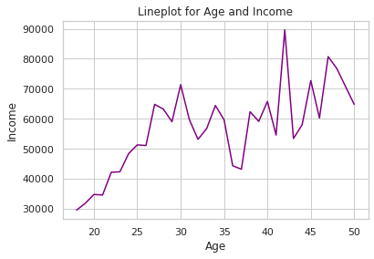

```python
sns.lineplot(x = 'Age', y = 'Income', data = data, color = 'purple',ci = None).set(title='Lineplot for Age and Income')
```

*Relationship between Usage and Miles*

```
[Text(0.5, 1.0, 'Lineplot for Usage and Miles')]
```

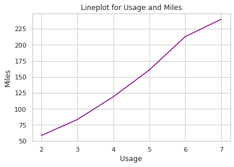

```python
sns.lineplot(x = 'Usage', y = 'Miles', data = data, color = 'purple',ci = None).set(title='Lineplot for Usage and Miles')
```

- From the graph, it is clear that the customers using the treadmill for more than 6 times a week are clocking more miles
- Linear trend indicating that the Miles covered increases as the usage increases

*Relationship between Usage and Fitness*

```
[Text(0.5, 1.0, 'Lineplot for Usage and Fitness')]
```

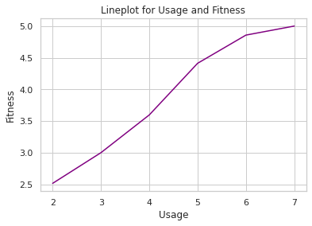

```python
sns.lineplot(x = 'Usage', y = 'Fitness', data = data, color = 'purple',ci = None).set(title='Lineplot for Usage and Fitness')
```

- From the graph, it is clear that the customers using the treadmill for more than 5 times a week are very active and fit
- Linear trend indicating that the fitness quotient increases as the usage increases

*Relationship between Fitness and Miles*

```
[Text(0.5, 1.0, 'Lineplot for Fitness and Miles')]
```

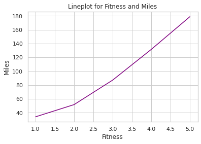

```python
sns.lineplot(x = 'Fitness', y = 'Miles', data = data, color = 'purple',ci = None).set(title='Lineplot for Fitness and Miles')
```

- From the graph, it is clear that there is a positive correlation with Miles covered/week
- Linear trend indicating that the fitness quotient increases as the miles covered per week increases

*Relationship between Income and Miles*

```
[Text(0.5, 1.0, 'Lineplot for Income and Miles')]
```

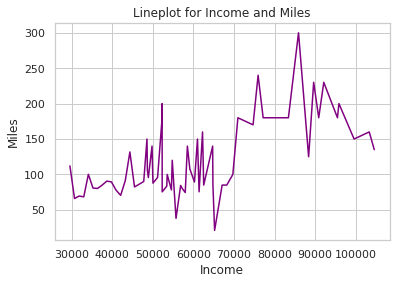

```python
sns.lineplot(x = 'Income', y = 'Miles', data = data, color = 'purple',ci = None).set(title='Lineplot for Income and Miles')
```

- From the graph, it is clear that the customers with more than 70K are running more ranging between 120-300 miles
- Customers with income less than 70 K are running less ranging between 30-150 mostly with few reaching 200 miles

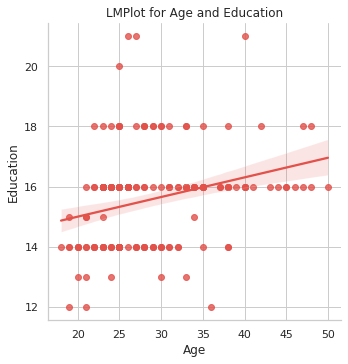

```python
sns.lmplot(data=data, x='Age', y='Education').set(title='LMPlot for Age and Education')
```

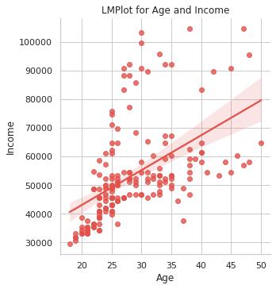

```python
sns.lmplot(data=data, x='Age', y='Income').set(title='LMPlot for Age and Income')
```

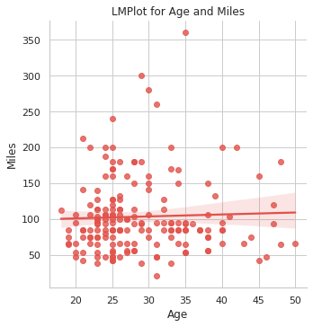

```python
sns.lmplot(data=data, x='Age', y='Miles').set(title='LMPlot for Age and Miles')
```

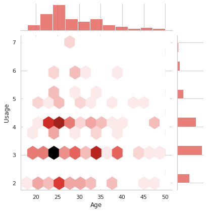

```python
sns.jointplot(data = data, x = 'Age', y = 'Usage', kind="hex")
```

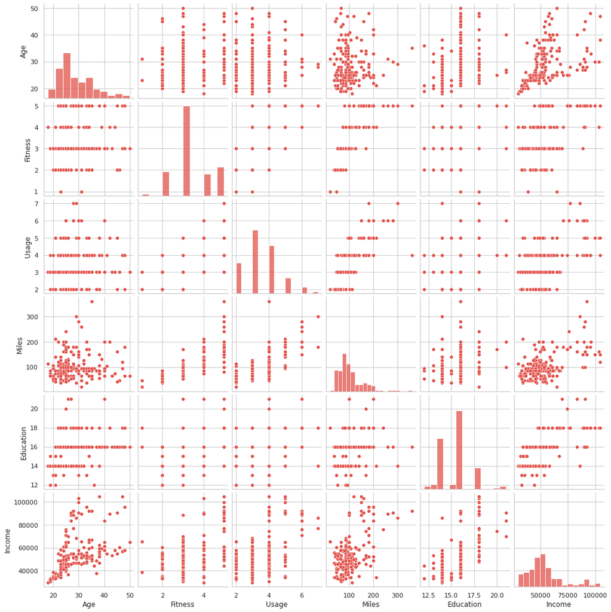

```python
sns.pairplot(data=data[['Age','Fitness','Usage','Miles','Education','Income']])
```

- From the graphs, it is clear that the Age and Income are positively correlated
- The relationship between data on skewness, correlation is depicted clearly from these plots

#### **Bi-Variate Analysis (Categorical Variables) to understand customer characteristics**

*Relationship between Product and Gender*

```
[Text(0.5, 1.0, 'Count Plot for Product against Gender')]
```

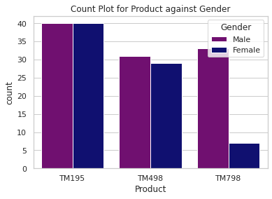

```python
sns.countplot(x = 'Product', data = data, palette=['Purple','Navy'], hue = 'Gender').set(title='Count Plot for Product against Gender')
```

- From the graph, it is clear that the TM195 is equally preferred by Male and Female customers
- Male Customers prefer TM798 mostly than females

*Relationship between Product and Marital Status*

```
[Text(0.5, 1.0, 'Count Plot for Product against Marital Status')]
```

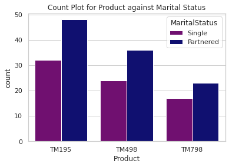

```python
sns.countplot(x = 'Product', data = data, palette=['Purple','Navy'], hue = 'MaritalStatus').set(title='Count Plot for Product against Marital Status')
```

- Partnered customers are having the treadmills more than the single customers

*Relationship between Gender and Marital Status*

```
[Text(0.5, 1.0, 'Count Plot for Gender against Marital status')]
```

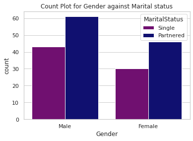

```python
sns.countplot(x = 'Gender', data = data, palette=['Purple','Navy'], hue = 'MaritalStatus').set(title='Count Plot for Gender against Marital status')
```

#### **Bi-Variate Analysis of Numerical Variables & Categorical Variables to understand Customer Patterns**

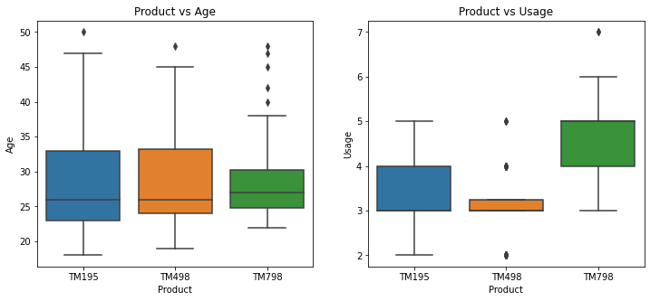

```python
plt.figure(figsize = (12,5))
plt.subplot(1,2,1)
sns.boxplot(data=data, x='Product', y='Age').set(title='Product vs Age')  ;
plt.subplot(1,2,2)
sns.boxplot(data = data, x='Product', y='Usage').set(title='Product vs Usage');
```

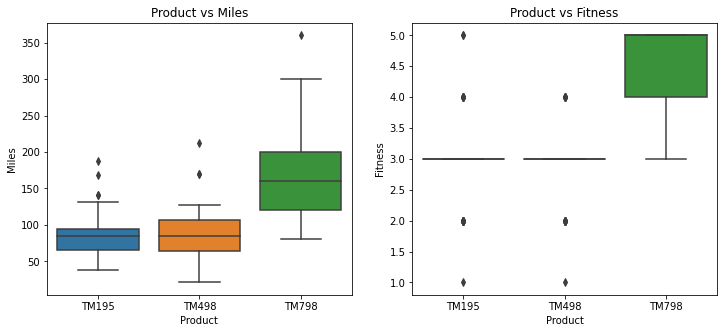

```python
plt.figure(figsize = (12,5))
plt.subplot(1,2,1)
sns.boxplot(data=data, x='Product', y='Miles').set(title='Product vs Miles')  ;
plt.subplot(1,2,2)
sns.boxplot(data = data, x='Product', y='Fitness').set(title='Product vs Fitness');
```

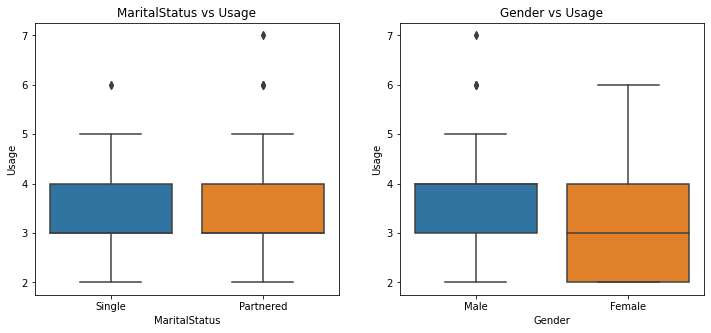

```python
plt.figure(figsize = (12,5))
plt.subplot(1,2,1)
sns.boxplot(data=data, x='MaritalStatus', y='Usage').set(title='MaritalStatus vs Usage')  ;
plt.subplot(1,2,2)
sns.boxplot(data = data, x='Gender', y='Usage').set(title='Gender vs Usage');
```

## **Observations**

**TM798**

- Minimum age of the customers is 22 and the maximum is 38
- Used minimum 3 days/week and maximum 6 days/week
- Minimum miles run/week is 80 and maximum is 300, with outliers until about 360 miles/week
- Minimum fitness rating is 3
- Minimum average annual income is 48k and the maximum is 104k IQR between 58k-91k

**Usage vs Marital Status Vs Gender**

- Average usage/week has significantly same values for the minimum usage/week which is 2 and maximum usage/week which is 5
- Outliers in case of married customers ranges until 7 days/week whereas for that of single customers it is only 6 days/week